# 1. Installation of the binary files

Maxime Lenormand, Boris Leroy and Pierre Denelle

2023-04-14

Some functions (listed below) or at least part of them require binary files to run.

- [netclu_infomap](https://bioRgeo.github.io/bioregion/reference/netclu_infomap.html)
- [netclu_louvain](https://bioRgeo.github.io/bioregion/reference/netclu_louvain.html) (Cpp version)
- [netclu_oslom](https://bioRgeo.github.io/bioregion/reference/netclu_oslom.html)

The function [install_binaries](https://bioRgeo.github.io/bioregion/reference/install_binaries.html) downloads and unzips the `bin` folder needed to run these functions. It also checks if the files have the permissions to be executed as programs. It finally tests if the binary files are running properly.

### Run install_binaries()

The function [install_binaries](https://bioRgeo.github.io/bioregion/reference/install_binaries.html) should be run prior to using [netclu_infomap](https://bioRgeo.github.io/bioregion/reference/netclu_infomap.html), the Cpp version of [netclu_louvain](https://bioRgeo.github.io/bioregion/reference/netclu_louvain.html) and [netclu_oslom](https://bioRgeo.github.io/bioregion/reference/netclu_oslom.html) as follows.

```r
install_binaries(binpath = "tempdir" , infomap_version = c("2.1.0", "2.6.0"))
```

The function has two parameters. `binpath` indicating the path to the folder that will host the `bin` folder containing the binary files. By default, the binary files are installed in R’s temporary directory (`binpath = "tempdir"`). In this case the `bin` folder will be automatically removed at the end of the R session. Alternatively, the binary files can be installed in the bioregion’s package folder (`binpath = "pkgfolder"`). **Any other folder can be chosen but in any case PLEASE MAKE SURE to update the binpath argument in [netclu_infomap](https://bioRgeo.github.io/bioregion/reference/netclu_infomap.html), [netclu_louvain](https://bioRgeo.github.io/bioregion/reference/netclu_louvain.html) and [netclu_oslom](https://bioRgeo.github.io/bioregion/reference/netclu_oslom.html) accordingly.**

The second parameter `infomap_version` indicating the Infomap version(s) to install. Only the Infomap version 2.1.0 and 2.6.0 are available for now.

The installation of the binary files is divided into six steps:

#### 1. Download bin.zip

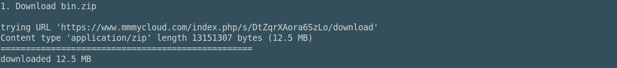

#### 2. Unzip bin.zip in the binpath

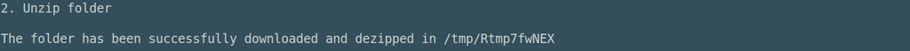

#### 3. Check the permissions, try to change them automatically or propose an iterative process to change them manually

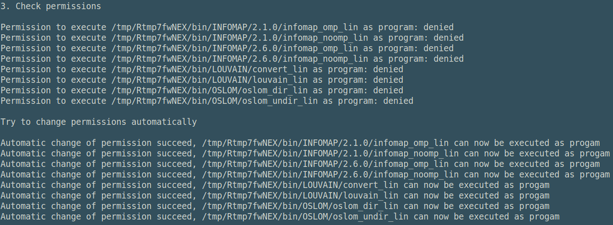

#### 4->6. Test that Infomap, Louvain and OSLOM are running properly

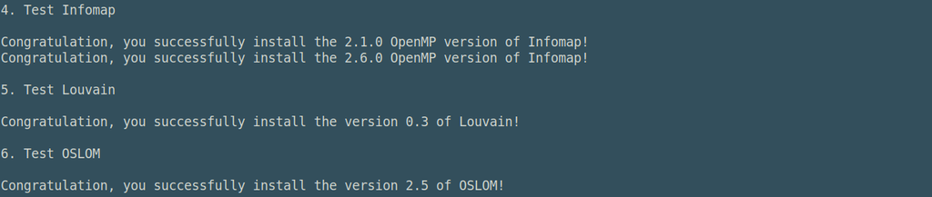

### Known issues

- The OpenMP versions of Infomap require `libomp-dev` on Ubuntu (`sudo apt-get install libomp-dev`) and `libomp` on macOS (install [Homebrew](https://brew.sh) and run `brew install libomp`).